# Trabajo_Final

```python
pip install bokeh
```

```python
import pandas as pd
from limpieza import *
import matplotlib.pyplot as pt
import numpy as np
import chardet
from bokeh.plotting import figure, show
```

```python
df_inftec = pd.read_csv('Cobertura_m_vil_por_tecnolog_a__departamento_y_municipio_por_proveedor_20240909.csv')
print(df_inftec.info())
```

```
<class 'pandas.core.frame.DataFrame'>
RangeIndex: 407281 entries, 0 to 407280
Data columns (total 16 columns):
 #   Column                    Non-Null Count   Dtype
---  ------                    --------------   -----
 0   AÑO                       407281 non-null  int64
 1   TRIMESTRE                 407281 non-null  int64
 2   PROVEEDOR                 407281 non-null  object
 3   COD DEPARTAMENTO          407281 non-null  int64
 4   DEPARTAMENTO              407281 non-null  object
 5   COD MUNICIPIO             407230 non-null  float64
 6   MUNICIPIO                 407281 non-null  object
 7   CABECERA MUNICIPAL        407281 non-null  object
 8   COD CENTRO POBLADO        407266 non-null  float64
 9   CENTRO POBLADO            407281 non-null  object
 10  COBERTURA 2G              407281 non-null  object
 11  COBERTURA 3G              407281 non-null  object
 12  COBERTURA HSPA+, HSPA+DC  407281 non-null  object
 13  COBERTUTA 4G              407281 non-null  object
 14  COBERTURA LTE             407281 non-null  object
 15  COBERTURA 5G              407281 non-null  object
dtypes: float64(2), int64(3), object(11)
memory usage: 49.7+ MB
None
```

- tenemos una Base de datos de 16 Columnas de diferentes tipos, lo primero que haremos es validar que la informacion esta limpia o hay que transformarla de alguna forma

```python
df_inftec
```

|  | AÑO | TRIMESTRE | PROVEEDOR | COD DEPARTAMENTO | DEPARTAMENTO | COD MUNICIPIO | MUNICIPIO | CABECERA MUNICIPAL | COD CENTRO POBLADO | CENTRO POBLADO | COBERTURA 2G | COBERTURA 3G | COBERTURA HSPA+, HSPA+DC | COBERTUTA 4G | COBERTURA LTE | COBERTURA 5G |
| --- | --- | --- | --- | --- | --- | --- | --- | --- | --- | --- | --- | --- | --- | --- | --- | --- |
| 0 | 2023 | 3 | COLOMBIA MOVIL S.A ESP | 27 | CHOCÓ | 27250.0 | EL LITORAL DEL SAN JUAN | N | 27250034.0 | TORDÓ | N | N | N | S | N | N |
| 1 | 2023 | 3 | COLOMBIA TELECOMUNICACIONES S.A. E.S.P. | 5 | ANTIOQUIA | 5495.0 | NECHÍ | N | 5495003.0 | LA CONCHA | S | S | S | S | N | N |
| 2 | 2022 | 3 | COLOMBIA MOVIL S.A ESP | 70 | SUCRE | 70508.0 | OVEJAS | N | 70508006.0 | DON GABRIEL | N | N | N | S | N | N |
| 3 | 2021 | 4 | AVANTEL S.A.S | 73 | TOLIMA | 73043.0 | ANZOÁTEGUI | S | 73043000.0 | ANZOÁTEGUI | S | S | S | N | N | N |
| 4 | 2021 | 2 | COMUNICACION CELULAR S A COMCEL S A | 50 | META | 50150.0 | CASTILLA LA NUEVA | N | 50150001.0 | SAN LORENZO | S | S | S | S | N | N |
| ... | ... | ... | ... | ... | ... | ... | ... | ... | ... | ... | ... | ... | ... | ... | ... | ... |
| 407276 | 2016 | 2 | COMUNICACION CELULAR S A COMCEL S A | 19 | CAUCA | 19001.0 | POPAYÁN | N | 0.0 | EL SENDERO | N | N | N | N | N | N |
| 407277 | 2017 | 1 | COMUNICACION CELULAR S A COMCEL S A | 52 | NARIÑO | 52001.0 | PASTO | N | 0.0 | BUESAQUILLO ALTO | N | N | N | N | N | N |
| 407278 | 2019 | 3 | COLOMBIA MOVIL S.A ESP | 25 | CUNDINAMARCA | 25899.0 | ZIPAQUIRÁ | S | 25899001.0 | ZIPAQUIRÁ | S | S | S | N | S | N |
| 407279 | 2017 | 3 | COMUNICACION CELULAR S A COMCEL S A | 17 | CALDAS | 17088.0 | BELALCÁZAR | N | 17088008.0 | ASENTAMIENTO INDÍGENA | N | N | N | N | N | N |
| 407280 | 2017 | 1 | COLOMBIA MOVIL S.A ESP | 52 | NARIÑO | 52693.0 | SAN PABLO | S | 52693001.0 | SAN PABLO | S | S | S | N | N | N |

407281 rows × 16 columns

- La base de datos es informativa, no contiene vales numericos realmente relevantes, los datos de analisis parecen ser tipo Bolean, donde se reporta el tipo de cobertura de internet a nivel nacional, En Colombia.

```python
for column in df_inftec:
    print(df_inftec[column].value_counts())
    print('\n')
```

```
AÑO
2016    54974
2019    54590
2017    53974
2018    52864
2020    49883
2021    48268
2022    45997
2023    33005
2015    13726
Name: count, dtype: int64


TRIMESTRE
4    103162
1    102178
2    101307
3    100634
Name: count, dtype: int64


PROVEEDOR
COMUNICACION CELULAR S A COMCEL S A                 244249
COLOMBIA TELECOMUNICACIONES S.A. E.S.P.              58507
COLOMBIA MOVIL  S.A ESP                              38024
AVANTEL S.A.S                                        26009
EMPRESA DE TELECOMUNICACIONES DE BOGOTA S.A. ESP     20584
PARTNERS TELECOM COLOMBIA SAS                        14588
ALMACENES EXITO INVERSIONES S.A.S.                    4573
UNE EPM TELECOMUNICACIONES S.A.                        747
Name: count, dtype: int64


COD DEPARTAMENTO
5     40224
25    33133
52    27835
76    26822
23    26799
13    21767
```

[output cut: 151 more lines]

```
COBERTUTA 4G
N    332166
S     75115
Name: count, dtype: int64


COBERTURA LTE
N    362403
S     44878
Name: count, dtype: int64


COBERTURA 5G
N    407281
Name: count, dtype: int64
```

```python
print(df_inftec.columns)
```

```
Index(['AÑO', 'TRIMESTRE', 'PROVEEDOR', 'COD DEPARTAMENTO', 'DEPARTAMENTO',
       'COD MUNICIPIO', 'MUNICIPIO', 'CABECERA MUNICIPAL',
       'COD CENTRO POBLADO', 'CENTRO POBLADO', 'COBERTURA 2G', 'COBERTURA 3G',
       'COBERTURA HSPA+, HSPA+DC', 'COBERTUTA 4G', 'COBERTURA LTE',
       'COBERTURA 5G'],
      dtype='object')
```

*una validacion adicional es ver si los valores de los Departamentos, municipios y poblados tienen una asignacion unica, es decir si un codigo no aparecen con diferentes nombres

```python
cod_lug = [3,5,8]
#cod_lug = [8]
i =0
tit = df_inftec.columns
while i < len(cod_lug):
    print(tit[cod_lug[i]])
    cod_dep = df_inftec[tit[cod_lug[i]]].unique()
    print(len(cod_dep))
    j =0
    num1=0
    while j < len(cod_dep):
        df_mod = df_inftec[df_inftec[tit[cod_lug[i]]] == cod_dep[j]]
        num_nom = df_mod[tit[cod_lug[i]+1]].unique()
        num = len(num_nom)
        if num != 1:
            print(f'el codigo {tit[cod_lug[i]]} el registro {cod_dep[j]} tiene {num} nombres y los registros son {num_nom}')
            num1 = len(df_mod) + num1
        j+=1
    if num1 > 1:
        print(f'el numero de incoherencias en esta columna son de {num1} \n')
    print('\n')
    i+=1
```

```
COD DEPARTAMENTO
33


COD MUNICIPIO
1122
el codigo COD MUNICIPIO el registro nan tiene 0 nombres y los registros son []


COD CENTRO POBLADO
8299
el codigo COD CENTRO POBLADO el registro 50150001.0 tiene 2 nombres y los registros son ['SAN LORENZO' 'CASTILLA LA NUEVA']
el codigo COD CENTRO POBLADO el registro 0.0 tiene 2272 nombres y los registros son ['VERACRUZ' 'LA CALIENTE' 'SIN CENTRO POBLADO' ... 'EL TABACO' 'TARAVIRA'
 'EL JOLON']
el codigo COD CENTRO POBLADO el registro 41503001.0 tiene 2 nombres y los registros son ['OPORAPA' 'SAN ROQUE']
el codigo COD CENTRO POBLADO el registro 50110001.0 tiene 2 nombres y los registros son ['SAN IGNACIO' 'BARRANCA DE UPÍA']
el codigo COD CENTRO POBLADO el registro 73268001.0 tiene 2 nombres y los registros son ['CHICORAL' 'ESPINAL']
el codigo COD CENTRO POBLADO el registro 76834001.0 tiene 2 nombres y los registros son ['TULUÁ' 'AGUACLARA']
el codigo COD CENTRO POBLADO el registro 47030001.0 tiene 2 nombres y los registros son ['BELLA VISTA' 'ALGARROBO']
el codigo COD CENTRO POBLADO el registro 47245001.0 tiene 2 nombres y los registros son ['AGUAESTRADA' 'EL BANCO']
el codigo COD CENTRO POBLADO el registro 52699001.0 tiene 2 nombres y los registros son ['SANTACRUZ' 'BALALAIKA']
el codigo COD CENTRO POBLADO el registro 73026001.0 tiene 2 nombres y los registros son ['CALDAS VIEJO' 'ALVARADO']
el codigo COD CENTRO POBLADO el registro 8520001.0 tiene 2 nombres y los registros son ['PALMAR DE VARELA' 'BURRUSCOS']
el codigo COD CENTRO POBLADO el registro 66440001.0 tiene 2 nombres y los registros son ['ALTO CAUCA' 'MARSELLA']
el codigo COD CENTRO POBLADO el registro 15720001.0 tiene 2 nombres y los registros son ['SATIVA VIEJO' 'SATIVANORTE']
el codigo COD CENTRO POBLADO el registro 20001001.0 tiene 2 nombres y los registros son ['AGUAS BLANCAS' 'VALLEDUPAR']
el codigo COD CENTRO POBLADO el registro 13873001.0 tiene 2 nombres y los registros son ['ZIPACOA' 'VILLANUEVA']
el codigo COD CENTRO POBLADO el registro 5045001.0 tiene 2 nombres y los registros son ['SAN JOSÉ DE APARTADÓ' 'APARTADÓ']
el codigo COD CENTRO POBLADO el registro 8638001.0 tiene 2 nombres y los registros son ['AGUADA DE PABLO' 'SABANALARGA']
el codigo COD CENTRO POBLADO el registro 73449001.0 tiene 2 nombres y los registros son ['CUALAMANÁ' 'MELGAR']
el codigo COD CENTRO POBLADO el registro 52687001.0 tiene 2 nombres y los registros son ['EL CARMEN' 'SAN LORENZO']
el codigo COD CENTRO POBLADO el registro 8421001.0 tiene 2 nombres y los registros son ['ARROYO DE PIEDRA' 'LURUACO']
el codigo COD CENTRO POBLADO el registro 13001001.0 tiene 2 nombres y los registros son ['ARROYO DE PIEDRA' 'CARTAGENA']
el codigo COD CENTRO POBLADO el registro 19397001.0 tiene 2 nombres y los registros son ['ALTAMIRA' 'LA VEGA']
el codigo COD CENTRO POBLADO el registro 63190001.0 tiene 2 nombres y los registros son ['LA POLA' 'CIRCASIA']
el codigo COD CENTRO POBLADO el registro 85010001.0 tiene 2 nombres y los registros son ['CUPIAGUA' 'AGUAZUL']
el codigo COD CENTRO POBLADO el registro 54405001.0 tiene 2 nombres y los registros son ['LA GARITA' 'LOS PATIOS']
el codigo COD CENTRO POBLADO el registro 8433001.0 tiene 2 nombres y los registros son ['CARACOLÍ' 'MALAMBO']
el codigo COD CENTRO POBLADO el registro 19290001.0 tiene 2 nombres y los registros son ['EL ROSARIO' 'FLORENCIA']
el codigo COD CENTRO POBLADO el registro 54128001.0 tiene 2 nombres y los registros son ['CACHIRÁ' 'LA CARRERA']
```

[output cut: 526 more lines]

```
el codigo COD CENTRO POBLADO el registro 5237001.0 tiene 2 nombres y los registros son ['BELLAVISTA' 'DONMATÍAS']
el codigo COD CENTRO POBLADO el registro 86755001.0 tiene 2 nombres y los registros son ['SAN FRANCISCO' 'SAN ANTONIO']
el codigo COD CENTRO POBLADO el registro 5425001.0 tiene 2 nombres y los registros son ['MACEO' 'LA SUSANA']
el codigo COD CENTRO POBLADO el registro 73547001.0 tiene 2 nombres y los registros son ['PIEDRAS' 'CHICALÁ']
el codigo COD CENTRO POBLADO el registro 19100001.0 tiene 2 nombres y los registros son ['CAPELLANÍAS' 'BOLÍVAR']
el codigo COD CENTRO POBLADO el registro 13430001.0 tiene 2 nombres y los registros son ['MAGANGUÉ' 'BARBOSA']
el codigo COD CENTRO POBLADO el registro 81001001.0 tiene 2 nombres y los registros son ['ARAUCA' 'CLARINETERO']
el codigo COD CENTRO POBLADO el registro 5585001.0 tiene 2 nombres y los registros son ['PUERTO NARE' 'ARABIA']
el codigo COD CENTRO POBLADO el registro 50680001.0 tiene 2 nombres y los registros son ['PAJURE' 'SAN CARLOS DE GUAROA']
el codigo COD CENTRO POBLADO el registro 5475001.0 tiene 2 nombres y los registros son ['MURINDÓ' 'OPOGADO']
el codigo COD CENTRO POBLADO el registro 73520001.0 tiene 2 nombres y los registros son ['PALOCABILDO' 'ASTURIAS']
el codigo COD CENTRO POBLADO el registro 19355001.0 tiene 2 nombres y los registros son ['INZÁ' 'CALDERAS']
el codigo COD CENTRO POBLADO el registro 52233001.0 tiene 2 nombres y los registros son ['CUMBITARA' 'DAMASCO']
el codigo COD CENTRO POBLADO el registro nan tiene 0 nombres y los registros son []
el numero de incoherencias en esta columna son de 127998
```

- trate de buscar los codigos en la Web y encontre una base de datos que tiene completa esta informacion.
- La fuente esta en https://geoportal.dane.gov.co/descargas/divipola/DIVIPOLA_CentrosPoblados.xlsx
- El cod Departamento es consistentes sin errores y limpio, lo mismo sucede con el Cod de Municipios solo que aca hay algunos valores como Na o vacios, no arrojo los nombres asociados a este cod vacio, por que debemos usar otra formulacion en este caso, a continuacion buscaremos los nombres.

```python
df_mod = df_inftec[df_inftec['COD MUNICIPIO'].isnull()]
print(f'para el campo vacio enconramos los siguientes municipios {df_mod['MUNICIPIO'].unique()}')
# Donde realmente solo hay un minucipio
```

```
para el campo vacio enconramos los siguientes municipios ['MAPIRIPANA']
```

- como vimos en el Cod de poblado si muestra mas de 127.000 registros inconsitentes, no los podemos eliminar ya que son casi la 4ta parte de toda la base.
- la otra opcion es realizar un cruce con la base encontrada de cod vs municipios para rellenar la informacion faltante y darle consistencia.
- hay una ultima validacion que deseo hacer antes de lo anterior y es ver si los codigos corresponden de manera logica o estos estan errados, es decir si se puede confiar en la informacion de la base.

```python
df_mod= df_inftec.copy()
df_mod['COD MUNICIPIO'] = df_mod['COD MUNICIPIO'].fillna(0)
df_mod['COD MUNICIPIO'] = df_mod['COD MUNICIPIO'].astype(int)
df_mod['COD MUNICIPIO'] = df_mod['COD MUNICIPIO'].astype(str)
df_mod['COD CENTRO POBLADO'] = df_mod['COD CENTRO POBLADO'].astype(str)
df_pru =df_mod[df_mod['COD MUNICIPIO'] != df_mod['COD CENTRO POBLADO'].str[:-5]]
df_pru =df_pru['COD CENTRO POBLADO'].unique()
print(df_pru)
print(len(df_pru))
print(len(df_mod[df_mod['COD MUNICIPIO'] != df_mod['COD CENTRO POBLADO'].str[:-5]]))
```

```
['0.0' 'nan']
2
55327
```

*la anterior prueba es para saber si los Cod de poblado son subcodigos del Cod Municipio, esto no se cumple en 55327 registros vacios. no se pueden eliminar por que superan el 10% de los datos.* lo que si tenemos son los nombres del poblado, usare este para reconstruir los codigos que faltan.

```python
with open('DIVIPOLA_CentrosPoblados.csv', 'rb') as f:
    result = chardet.detect(f.read())
print(result['encoding'])
```

```
ISO-8859-1
```

```python
df_base = pd.read_csv('DIVIPOLA_CentrosPoblados.csv', encoding = 'cp1252', sep=';')
print(df_base.info())
```

```
<class 'pandas.core.frame.DataFrame'>
RangeIndex: 8157 entries, 0 to 8156
Data columns (total 9 columns):
 #   Column     Non-Null Count  Dtype
---  ------     --------------  -----
 0   Código     8157 non-null   int64
 1   dep        8157 non-null   object
 2   Código .1  8157 non-null   int64
 3   mun        8157 non-null   object
 4   Código .2  8157 non-null   int64
 5   poblado    8157 non-null   object
 6   Tipo
      8157 non-null   object
 7   Longitud   7728 non-null   object
 8   Latitud    7728 non-null   object
dtypes: int64(3), object(6)
memory usage: 573.7+ KB
None
```

```python
df_base['indic1']= df_base['Código .1'].astype(str) + df_base['poblado']
df_mod['POB MUN'] = df_mod['COD MUNICIPIO'] + df_mod['CENTRO POBLADO']
#CREO un indicador de busqueda uniendo 2 columnas
```

```python
var_vac=df_mod[df_mod['COD MUNICIPIO'] != df_mod['COD CENTRO POBLADO'].str[:-5]].copy()
var_vac= var_vac['POB MUN'].unique()
print(var_vac)
# estas son las poblaciones que no tienen codigo
```

```
['20001VERACRUZ' '5736LA CALIENTE' '5659SIN CENTRO POBLADO' ...
 '70823SIN CENTRO POBLADO' '19318SAN FRANCISCO' '20383SIN CENTRO POBLADO']
```

```python
i =0
sum =0
while i < len(var_vac):
    df_pru = df_base[df_base['indic1'].isin([var_vac[i]])==True]

    if len(df_pru) ==1:
        df_mod['COD CENTRO POBLADO']= np.where(df_mod['POB MUN']== var_vac[i],df_pru['Código .2'],df_mod['COD CENTRO POBLADO'])
    i+=1
```

```python
len(df_mod[df_mod['COD MUNICIPIO'] != df_mod['COD CENTRO POBLADO'].str[:-5]])
```

```
55687
```

*Definitivamente, cualquier intento por arreglar la base de codigos vacios, es imposible de reconstruir, lo unico es reorganizar los nombres del Cod Poblado que estan mal y eliminar los registros malos que no tienen coherencia o por lo menos a la hora de hacer analisis con este campo.

```python
df_mod = df_mod.drop('CENTRO POBLADO', axis =1)
```

```python
df_mod['COD CENTRO POBLADO']=df_mod['COD CENTRO POBLADO'].astype(str)
df_base['Código .2'] = df_base['Código .2'].astype(str)
df_base.info()
df_mod.info()
```

```
<class 'pandas.core.frame.DataFrame'>
RangeIndex: 8157 entries, 0 to 8156
Data columns (total 10 columns):
 #   Column     Non-Null Count  Dtype
---  ------     --------------  -----
 0   Código     8157 non-null   int64
 1   dep        8157 non-null   object
 2   Código .1  8157 non-null   int64
 3   mun        8157 non-null   object
 4   Código .2  8157 non-null   object
 5   poblado    8157 non-null   object
 6   Tipo
      8157 non-null   object
 7   Longitud   7728 non-null   object
 8   Latitud    7728 non-null   object
 9   indic1     8157 non-null   object
dtypes: int64(2), object(8)
memory usage: 637.4+ KB
<class 'pandas.core.frame.DataFrame'>
RangeIndex: 407281 entries, 0 to 407280
Data columns (total 16 columns):
 #   Column                    Non-Null Count   Dtype
---  ------                    --------------   -----
 0   AÑO                       407281 non-null  int64
 1   TRIMESTRE                 407281 non-null  int64
 2   PROVEEDOR                 407281 non-null  object
 3   COD DEPARTAMENTO          407281 non-null  int64
 4   DEPARTAMENTO              407281 non-null  object
 5   COD MUNICIPIO             407281 non-null  object
 6   MUNICIPIO                 407281 non-null  object
 7   CABECERA MUNICIPAL        407281 non-null  object
 8   COD CENTRO POBLADO        407281 non-null  object
 9   COBERTURA 2G              407281 non-null  object
 10  COBERTURA 3G              407281 non-null  object
 11  COBERTURA HSPA+, HSPA+DC  407281 non-null  object
 12  COBERTUTA 4G              407281 non-null  object
 13  COBERTURA LTE             407281 non-null  object
 14  COBERTURA 5G              407281 non-null  object
 15  POB MUN                   407281 non-null  object
dtypes: int64(3), object(13)
memory usage: 49.7+ MB
```

```python
df_base['Código .2'] =df_base['Código .2'].astype(str)
df_con = df_mod.copy()
df_con = pd.merge(df_con,df_base, how = 'left',right_on='indic1', left_on='POB MUN')
print(df_con.info())
df_con
```

```
<class 'pandas.core.frame.DataFrame'>
RangeIndex: 407281 entries, 0 to 407280
Data columns (total 26 columns):
 #   Column                    Non-Null Count   Dtype
---  ------                    --------------   -----
 0   AÑO                       407281 non-null  int64
 1   TRIMESTRE                 407281 non-null  int64
 2   PROVEEDOR                 407281 non-null  object
 3   COD DEPARTAMENTO          407281 non-null  int64
 4   DEPARTAMENTO              407281 non-null  object
 5   COD MUNICIPIO             407281 non-null  object
 6   MUNICIPIO                 407281 non-null  object
 7   CABECERA MUNICIPAL        407281 non-null  object
 8   COD CENTRO POBLADO        407281 non-null  object
 9   COBERTURA 2G              407281 non-null  object
```

[output cut: 20 more lines]

|  | AÑO | TRIMESTRE | PROVEEDOR | COD DEPARTAMENTO | DEPARTAMENTO | COD MUNICIPIO | MUNICIPIO | CABECERA MUNICIPAL | COD CENTRO POBLADO | COBERTURA 2G | ... | Código | dep | Código .1 | mun | Código .2 | poblado | Tipo\n | Longitud | Latitud | indic1 |
| --- | --- | --- | --- | --- | --- | --- | --- | --- | --- | --- | --- | --- | --- | --- | --- | --- | --- | --- | --- | --- | --- |
| 0 | 2023 | 3 | COLOMBIA MOVIL S.A ESP | 27 | CHOCÓ | 27250 | EL LITORAL DEL SAN JUAN | N | 27250034.0 | N | ... | 27.0 | CHOCÓ | 27250.0 | EL LITORAL DEL SAN JUAN | 27250034 | TORDÓ | CP | -77,016844 | 4,337722 | 27250TORDÓ |
| 1 | 2023 | 3 | COLOMBIA TELECOMUNICACIONES S.A. E.S.P. | 5 | ANTIOQUIA | 5495 | NECHÍ | N | 5495003.0 | S | ... | 5.0 | ANTIOQUIA | 5495.0 | NECHÍ | 5495003 | LA CONCHA | CP | -74,868204 | 7,948383 | 5495LA CONCHA |
| 2 | 2022 | 3 | COLOMBIA MOVIL S.A ESP | 70 | SUCRE | 70508 | OVEJAS | N | 70508006.0 | N | ... | 70.0 | SUCRE | 70508.0 | OVEJAS | 70508006 | DON GABRIEL | CP | -75,293051 | 9,623491 | 70508DON GABRIEL |
| 3 | 2021 | 4 | AVANTEL S.A.S | 73 | TOLIMA | 73043 | ANZOÁTEGUI | S | 73043000.0 | S | ... | 73.0 | TOLIMA | 73043.0 | ANZOÁTEGUI | 73043000 | ANZOÁTEGUI | CM | -75,096451 | 4,627474 | 73043ANZOÁTEGUI |
| 4 | 2021 | 2 | COMUNICACION CELULAR S A COMCEL S A | 50 | META | 50150 | CASTILLA LA NUEVA | N | 50150001.0 | S | ... | 50.0 | META | 50150.0 | CASTILLA LA NUEVA | 50150001 | SAN LORENZO | CP | -73,548038 | 3,811495 | 50150SAN LORENZO |
| ... | ... | ... | ... | ... | ... | ... | ... | ... | ... | ... | ... | ... | ... | ... | ... | ... | ... | ... | ... | ... | ... |
| 407276 | 2016 | 2 | COMUNICACION CELULAR S A COMCEL S A | 19 | CAUCA | 19001 | POPAYÁN | N | 0.0 | N | ... | NaN | NaN | NaN | NaN | NaN | NaN | NaN | NaN | NaN | NaN |
| 407277 | 2017 | 1 | COMUNICACION CELULAR S A COMCEL S A | 52 | NARIÑO | 52001 | PASTO | N | 0.0 | N | ... | NaN | NaN | NaN | NaN | NaN | NaN | NaN | NaN | NaN | NaN |
| 407278 | 2019 | 3 | COLOMBIA MOVIL S.A ESP | 25 | CUNDINAMARCA | 25899 | ZIPAQUIRÁ | S | 25899001.0 | S | ... | 25.0 | CUNDINAMARCA | 25899.0 | ZIPAQUIRÁ | 25899000 | ZIPAQUIRÁ | CM | -73,994434 | 5,02544 | 25899ZIPAQUIRÁ |
| 407279 | 2017 | 3 | COMUNICACION CELULAR S A COMCEL S A | 17 | CALDAS | 17088 | BELALCÁZAR | N | 17088008.0 | N | ... | NaN | NaN | NaN | NaN | NaN | NaN | NaN | NaN | NaN | NaN |
| 407280 | 2017 | 1 | COLOMBIA MOVIL S.A ESP | 52 | NARIÑO | 52693 | SAN PABLO | S | 52693001.0 | S | ... | 52.0 | NARIÑO | 52693.0 | SAN PABLO | 52693000 | SAN PABLO | CM | -77,013984 | 1,669429 | 52693SAN PABLO |

407281 rows × 26 columns

```python
df_con=df_con.drop(['dep','Código .1','mun','Código .2','Código ','indic1'],axis=1)
```

```python
df_pru = df_con.copy()
indic =df_pru[df_pru['Longitud'].isnull()].index
df_pru=df_pru.drop(indic)
df_pru.info()
```

```
<class 'pandas.core.frame.DataFrame'>
Index: 329836 entries, 0 to 407280
Data columns (total 20 columns):
 #   Column                    Non-Null Count   Dtype
---  ------                    --------------   -----
 0   AÑO                       329836 non-null  int64
 1   TRIMESTRE                 329836 non-null  int64
 2   PROVEEDOR                 329836 non-null  object
 3   COD DEPARTAMENTO          329836 non-null  int64
 4   DEPARTAMENTO              329836 non-null  object
 5   COD MUNICIPIO             329836 non-null  object
 6   MUNICIPIO                 329836 non-null  object
 7   CABECERA MUNICIPAL        329836 non-null  object
 8   COD CENTRO POBLADO        329836 non-null  object
 9   COBERTURA 2G              329836 non-null  object
 10  COBERTURA 3G              329836 non-null  object
 11  COBERTURA HSPA+, HSPA+DC  329836 non-null  object
 12  COBERTUTA 4G              329836 non-null  object
 13  COBERTURA LTE             329836 non-null  object
 14  COBERTURA 5G              329836 non-null  object
 15  POB MUN                   329836 non-null  object
 16  poblado                   329836 non-null  object
 17  Tipo
                     329836 non-null  object
 18  Longitud                  329836 non-null  object
 19  Latitud                   329836 non-null  object
dtypes: int64(3), object(17)
memory usage: 52.8+ MB
```

*Desde ahora tenemos una base bastante buena para analizar

```python
#organizar eje x y y empresas vs cobertura
x = df_con['PROVEEDOR'].unique()
y = []
i=0
while i <len(x):
    y.append(len(df_con[df_con['PROVEEDOR']==x[i]]))
    i+=1
print(x)
print(y)

#df_con.columns
```

```
['COLOMBIA MOVIL  S.A ESP' 'COLOMBIA TELECOMUNICACIONES S.A. E.S.P.'
 'AVANTEL S.A.S' 'COMUNICACION CELULAR S A COMCEL S A'
 'EMPRESA DE TELECOMUNICACIONES DE BOGOTA S.A. ESP'
 'PARTNERS TELECOM COLOMBIA SAS' 'ALMACENES EXITO INVERSIONES S.A.S.'
 'UNE EPM TELECOMUNICACIONES S.A.']
[38024, 58507, 26009, 244249, 20584, 14588, 4573, 747]
```

```python
# create a new plot with a title and axis labels

p = figure(title="Cobertura en el mercado", x_axis_label='x', y_axis_label='y')
# add a line renderer with legend and line thickness to the plot
p.line(x, y, legend_label="Temp.", line_width=2)
show(p)
```

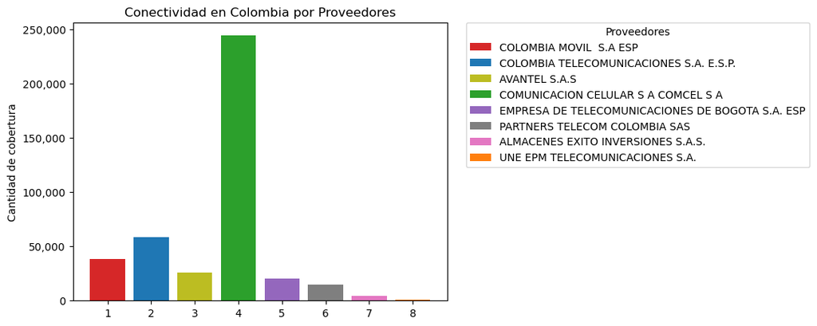

```python
fig, ax = pt.subplots()

num = [1,2,3,4,5,6,7,8]
bar_labels = ['red', 'blue', '_red', 'orange']
bar_colors = ['tab:red', 'tab:blue', 'tab:olive','tab:green','tab:purple','tab:gray','tab:pink', 'tab:orange']

ax.bar(num, y, label=x, color=bar_colors)

ax.set_ylabel('Cantidad de cobertura')
ax.set_title('Conectividad en Colombia por Proveedores')
ax.legend(title='Proveedores',bbox_to_anchor=(1.05,1), loc="upper left",borderaxespad = 0.)
ax.yaxis.set_major_formatter('{x:,.0f}')
pt.show()
```

# Segun tipos de red

```python
red = ['COBERTURA 2G', 'COBERTURA 3G','COBERTURA HSPA+, HSPA+DC','COBERTUTA 4G','COBERTURA LTE','COBERTURA 5G']
lista =[]
data = []
print(df_con[red[0]].unique())
len(df_con[df_con[red[0]]=='S'])
#print(df_con[df_con[red[0]]=='S'])
print(x)
```

```
['N' 'S']
['COLOMBIA MOVIL  S.A ESP' 'COLOMBIA TELECOMUNICACIONES S.A. E.S.P.'
 'AVANTEL S.A.S' 'COMUNICACION CELULAR S A COMCEL S A'
 'EMPRESA DE TELECOMUNICACIONES DE BOGOTA S.A. ESP'
 'PARTNERS TELECOM COLOMBIA SAS' 'ALMACENES EXITO INVERSIONES S.A.S.'
 'UNE EPM TELECOMUNICACIONES S.A.']
```

```python
print(len(red)-1)
```

```
5
```

```python
lista =[]
data = []
i=len(red)-1
while i >=0:
    lista =[]
    j=0
    while j <len(x):
        lista.append(len(df_con[(df_con[red[i]]=='S')&(df_con['PROVEEDOR']==x[j])]))
        j+=1
    data.append(lista)
    i=i-1
print(data)
#df_con.columns
```

```
[[0, 0, 0, 0, 0, 0, 0, 0], [5597, 6996, 1352, 25124, 4951, 0, 471, 387], [16084, 13180, 3101, 32117, 1220, 9413, 0, 0], [30207, 19731, 6600, 75936, 8649, 11227, 3237, 0], [31766, 44943, 6600, 90524, 10438, 11227, 4021, 0], [27873, 50889, 11451, 112259, 10507, 7, 4245, 0]]
```

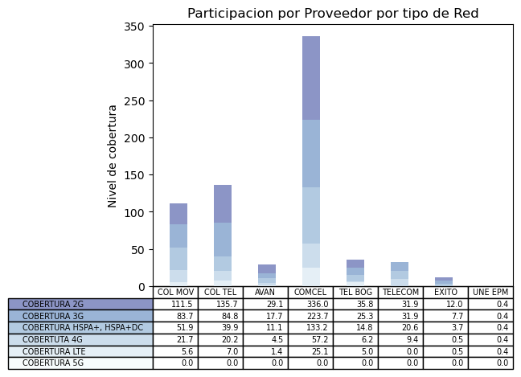

```python
columns = ['COL MOV', 'COL TEL', 'AVAN', 'COMCEL', 'TEL BOG', 'TELECOM', 'EXITO', 'UNE EPM']
#rows = ['%d year' % x for x in (1,2,3,4,5,6)]
rows = red

values = np.arange(0, 370, 50)
value_increment = 1000

# Get some pastel shades for the colors
colors = pt.cm.BuPu(np.linspace(0, 0.5, len(rows)))
n_rows = len(data)

index = np.arange(len(columns)) + 0.3
bar_width = 0.4

# Initialize the vertical-offset for the stacked bar chart.
y_offset = np.zeros(len(columns))

# Plot bars and create text labels for the table
cell_text = []
for row in range(n_rows):
    pt.bar(index, data[row], bar_width, bottom=y_offset, color=colors[row])
    y_offset = y_offset + data[row]
    cell_text.append(['%1.1f' % (x / 1000.0) for x in y_offset])
# Reverse colors and text labels to display the last value at the top.
colors = colors[::-1]
cell_text.reverse()

# Add a table at the bottom of the Axes
the_table = pt.table(cellText=cell_text,
                      rowLabels=rows,
                      rowColours=colors,
                      colLabels=columns,
                      loc='bottom')

# Adjust layout to make room for the table:
pt.subplots_adjust(left=0.2, bottom=0.2)
pt.ylabel(f"Nivel de cobertura")
pt.yticks(values * value_increment, ['%d' % val for val in values])
pt.xticks([])
pt.title('Participacion por Proveedor por tipo de Red')
fig = pt.figure(figsize = (23,6))
pt.show()
```

```python
df_con.columns
```

```
Index(['AÑO', 'TRIMESTRE', 'PROVEEDOR', 'COD DEPARTAMENTO', 'DEPARTAMENTO',
       'COD MUNICIPIO', 'MUNICIPIO', 'CABECERA MUNICIPAL',
       'COD CENTRO POBLADO', 'COBERTURA 2G', 'COBERTURA 3G',
       'COBERTURA HSPA+, HSPA+DC', 'COBERTUTA 4G', 'COBERTURA LTE',
       'COBERTURA 5G', 'POB MUN', 'poblado', 'Tipo\n', 'Longitud', 'Latitud'],
      dtype='object')
```

```python
df_con['Latitud']=df_con['Latitud'].str.replace(',','.').astype("float")
df_con['Longitud']=df_con['Longitud'].str.replace(',','.').astype("float")
```

```python
print(df_con['COBERTURA 2G'].isin(["S"]).sum())
pobla = df_con['DEPARTAMENTO'].unique()
i = 0
g2x = []
g3x  = []
hspax= []
g2y = []
g3y  = []
hspay= []
g2a = []
g3a  = []
hspaa= []

print(pobla[0])

while i < len(pobla):

    g2ba= df_con[(df_con['DEPARTAMENTO']==pobla[i])&(df_con['COBERTURA 2G']=="S")]
    #g3ba= df_con[(df_con['POB MUN']==pobla[i])&(df_con['COBERTURA 3G']=="S")]
    #hspaba= df_con[(df_con['POB MUN']==pobla[i])&(df_con['COBERTURA HSPA+, HSPA+DC']=="S")]
    #if g2ba.empty:
        #g2x.append(0)
        #g3x.append(0)
        #hspax.append(hspaba['Longitud'].mean)

        #g2y.append(0)
        #g3y.append(g3ba['Latitud'].mean)
        #hspay.append(hspaba['Latitud'].mean)

        #g2a.append(0)
        #g3a.append(len(df_con[(df_con['POB MUN']==pobla[i])&(df_con['COBERTURA 3G']=="S")]))
        #hspaa.append(len(df_con[(df_con['POB MUN']==pobla[i])&(df_con['COBERTURA HSPA+, HSPA+DC']=="S")]))
    #else:
    g2x.append(g2ba['Longitud'].mean())
        #g3x.append(g3ba['Longitud'].mean)
        #hspax.append(hspaba['Longitud'].mean)

    g2y.append(g2ba['Latitud'].mean())
        #g3y.append(g3ba['Latitud'].mean)
        #hspay.append(hspaba['Latitud'].mean)

    g2a.append(len(df_con[(df_con['DEPARTAMENTO']==pobla[i])&(df_con['COBERTURA 2G']=="S")])/70)
        #g3a.append(len(df_con[(df_con['POB MUN']==pobla[i])&(df_con['COBERTURA 3G']=="S")]))
        #hspaa.append(len(df_con[(df_con['POB MUN']==pobla[i])&(df_con['COBERTURA HSPA+, HSPA+DC']=="S")]))
    i+=1
print(g2x)
print(g2y)
print(g2a)
```

```
217231
CHOCÓ
[-76.81310273259187, -75.58731683988563, -75.25884778217822, -75.0618512832047, -73.44496055831308, -73.57004325680204, -71.39110060013003, -72.7847323081887, -73.2550003872192, -74.19349600807129, -75.34505646995073, -77.59406026574996, -75.77194154316791, -72.7781864708376, -74.79300099938933, -76…
[5.895184150870406, 6.630109806443378, 9.232826276784394, 4.2658326361697805, 3.771647912356821, 9.31092124876022, 6.809977937581275, 11.155077105473964, 5.667903908925318, 4.82509099384156, 1.3919640374384237, 1.3193516817735373, 4.9428646285973254, 7.9524206534132444, 9.483339656110966, 2.51226891…
[37.6, 310.75714285714287, 105.5, 149.37142857142857, 85.71428571428571, 113.6, 23.65714285714286, 69.92857142857143, 194.72857142857143, 324.04285714285714, 30.614285714285714, 119.8, 65.54285714285714, 105.12857142857143, 177.24285714285713, 110.72857142857143, 42.72857142857143, 126.4, 167.771428…
```

- El codigo anterior logra hacer un detalle organizado por departamentos de su ubicacion espacial (Longitud y Latitud), y la densidad se define como ell numero de veces que aparece la red en los poblados de ese departamento. Es decir un conteo a nivel de registros.
- Pero cuando trato de ejecutar el mismo codigo para un nivel mas detallado, es decir por poblados, este se cuelga y no opera. quisiera saber si hay una estructura mas sencilla que el for o while para realizar este tipo de obtencion de datos. Muchas gracias de antemano.

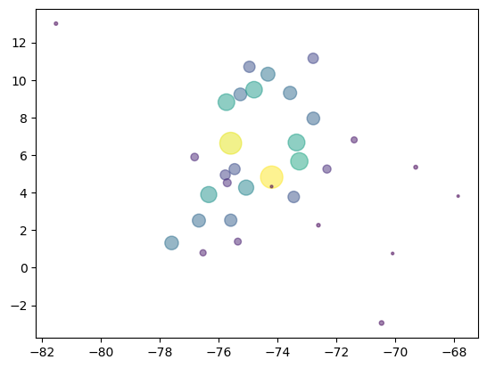

```python
x = g2x
y = g2y
colors = g2a
area = g2a

pt.scatter(x, y, s=area, c=colors, alpha=0.5)
pt.show()
```

*como vemos el grafico nos expresa, geograficamente donde esta la mayor concentracion telefonia de cobertura 2g, iaguinandonos que el grafico esta plasmado sobre el mapa de Colombia, veremos que la red se distribuye mas al centro del Pais, en ciudades principales como Bogota, CAli, Medellin entre otras y hay una baja densidad en las partes externas del Pais, los putos distantes pueden ser San ANdres por arriba y Amazonas por abajo.